# CitiBike Weather Kenny

Kenneth Andrysiak

12/3/2021

# What Does the Data Look Like?

```r
#Reading the Libraries
library(ggpubr)
library(ggplot2)
library(dplyr)
library(gganimate)
library(tidyr)
library(stringr)
library(geosphere)
library(leaflet)
library(janitor)

#Importing the data
citi <- read.csv("citicleaned.csv")
citi <- clean_names(citi)

citi$start_station_name <- as.factor(citi$start_station_name)
citi$start_station_id <- as.factor(citi$start_station_id)
citi$end_station_name <- as.factor(citi$end_station_name)
citi$end_station_id <- as.factor(citi$end_station_id)
citi$usertype <- as.factor(citi$usertype)
citi$gender <- as.factor(citi$gender)
citi$dayid <- as.factor(citi$dayid)
citi$DATE <- as.Date(citi$starttime, format = "%Y-%m-%d")

#str(citi)

weather <- read.csv("NYCWeather2019.csv")
weather$STATION <- NULL
weather$NAME <- NULL
weather$DATE <- as.Date(weather$DATE, format= "%m/%d/%Y")
weather$TAVG <- (weather$TMAX + weather$TMIN)/2

#str(weather)

citimerged <- merge(citi,weather, by = "DATE")
str(citimerged)
```

```
## 'data.frame':    205518 obs. of  33 variables:
##  $ DATE                   : Date, format: "2019-01-01" "2019-01-01" ...
##  $ x                      : int  7161 3876 1367 1811 6371 6184 9546 4445 8032 4403 ...
##  $ tripduration           : int  2006 84 335 400 371 1016 1767 1571 473 2786 ...
##  $ starttime              : chr  "2019-01-01 15:47:35" "2019-01-01 17:29:25" "2019-01-01 12:48:47" "2019-01-01 11:17:31" ...
##  $ stoptime               : chr  "2019-01-01 16:21:02" "2019-01-01 17:30:50" "2019-01-01 12:54:22" "2019-01-01 11:24:12" ...
##  $ start_station_id       : Factor w/ 828 levels "116","119","120",..: 806 237 334 217 345 800 345 82 170 731 ...
##  $ start_station_name     : Factor w/ 910 levels "1 Ave & E 110 St",..: 848 409 233 858 253 23 253 359 702 423 ...
##  $ start_station_latitude : num  40.8 40.8 40.7 40.8 40.8 ...
##  $ start_station_longitude: num  -74 -74 -74 -74 -74 ...
##  $ end_station_id         : Factor w/ 831 levels "116","119","120",..: 324 183 601 265 349 312 23 427 561 226 ...
##  $ end_station_name       : Factor w/ 913 levels "1 Ave & E 110 St",..: 788 7 752 872 251 814 252 875 119 223 ...
##  $ end_station_latitude   : num  40.8 40.8 40.7 40.8 40.8 ...
##  $ end_station_longitude  : num  -74 -74 -74 -74 -74 ...
##  $ bikeid                 : int  32722 31540 33952 25714 26679 33277 28700 28721 33954 26409 ...
```

[output cut: 19 more lines]

```r
View(citimerged)
```

# Does Temperature Affect the Number of Trips that are Taken?

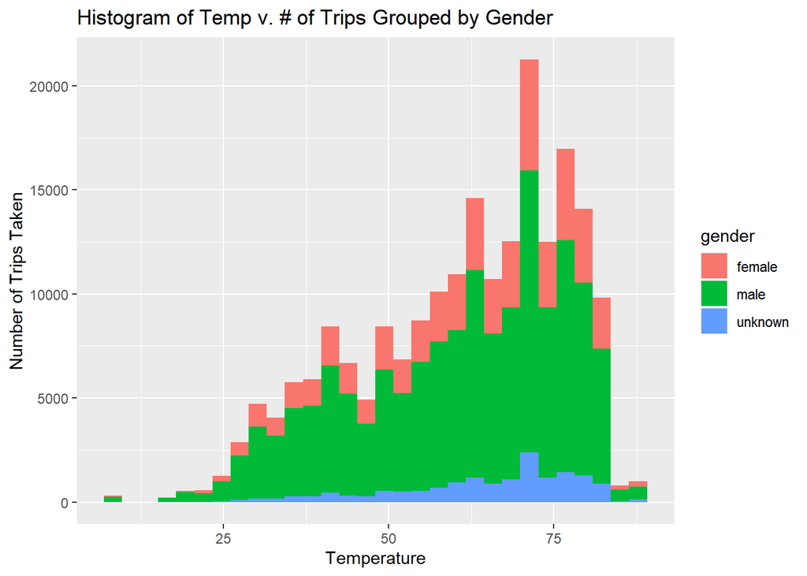

```r
#Bar Chart of Rides Based on Temperature
tempgenderchart <- ggplot(citimerged, aes(x = TAVG, fill = gender)) + geom_histogram() + xlab("Temperature") + ylab("Number of Trips Taken") + ggtitle("Histogram of Temp v. # of Trips Grouped by Gender")
tempgenderchart
```

As we see here, there is a considerable amount of our consumer base that is male compared to female. That being said, the proportion remains fairly consistent across the different temperatures and should be a point of emphasis in our marketing. However, it should be noted that the number of trips as temperature increases is significant and should be noted for the months in which there are higher/lower temperatures. In terms of a utilization strategy, it makes sense that we should have less bikes on the street during the winter months, one because the data suggests that there is a significant correlation with the number of trips that are taken and the temperature. We suggest a utilization strategy that continues to increase the number of bikes on the street as the year goes on and the temperatures get warmer. It tracks in the other direction as well. As winter comes along, we should begin decreasing the number of bikes on the street.

# How Does Temperature Change Across the Months?

[figure not shown]

```r
animatetempchart <- ggplot(citimerged, aes(DATE, TAVG, group = month, colour = factor(month))) + geom_line() + xlab("Date") + ylab("Temperature") + ggtitle("Change in Temperature Over Time") + transition_reveal(DATE)
animatetempchart
```

This animated chart is meant to inform the management on temperature movements thorughout the year for the purposes of fulfilling the aforementioned plan to have less bikes on the streets when its too hot/too cold, based on the graph that we have depicted first in this section of the Report. If we run a cross section, it would makes sense to have all of our bikes on the road from the months of May through the end of October. In the other months, we can have less bikes on the streets without having to worry about utilization issues, except for those stations that we are going to discuss later in this report.

# What effect does Temperature Have on the Speed of Riders?

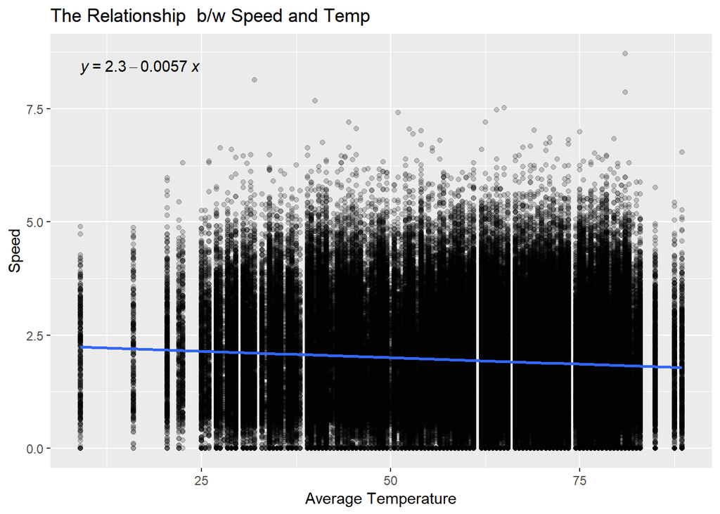

```r
tempspeedchart <- ggplot(citimerged, aes(x = TAVG, y = speed)) + geom_point(alpha = 0.2) + geom_smooth(method = lm) + stat_regline_equation() + xlab("Average Temperature") + ylab("Speed") + ggtitle("The Relationship  b/w Speed and Temp")
tempspeedchart
```

The main point of analyzing the speed of riders is to know how fast they are getting from point A to point B in order to fulfill our services to other customers that may be waiting for bikes at a specific station and/or lookng for a station with Bikes. The faster riders go, the less time they spend on bikes. That being said, we see here that as temperature increases, there is a negative trend to speed. This means that in the summer months, there are probably more leisure riders tying to see the city rather than get to point B as fast as possible. In addition to this, we ned to consider the relationship in the context of utilization. As stated before, we are looking to have the least amount of wait times for our customers as possible with high, but not overburdened utilization. This means that we should expect there to be higher capacity utilization in the months where it is warmer due to reduced speeds of our riders.

# What Effect does Temperature Have on the Distance of Trips?

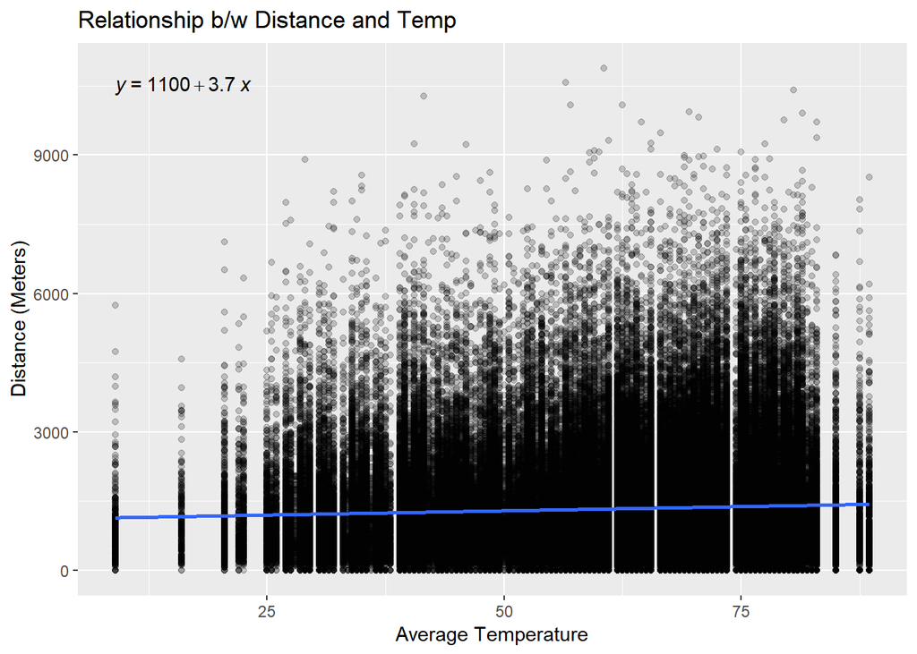

```r
tempdistchart <- ggplot(citimerged, aes(x = TAVG, y = distmeters)) + geom_point(alpha = 0.2) + geom_smooth(method = lm) + stat_regline_equation() + xlab("Average Temperature") + ylab("Distance (Meters)") + ggtitle("Relationship b/w Distance and Temp")
tempdistchart
```

Simply put, this graph shows the relationship between distance traveled and the average temperature on any given day. It has a possitive relationship, meaning that as the days get warmer, we can expect there to be a majority of rides that incrase in distance. Again, it all goes back to utilization, and the longer that riders travel, the longer they are on the bike, all else equal. We expect this to add to our point that utilization will most likely be near, if not at, 100% for a majority of our bike stations during the months where it is warmer.

# What Effect Does Precipitation Have on the Speed of Riders?

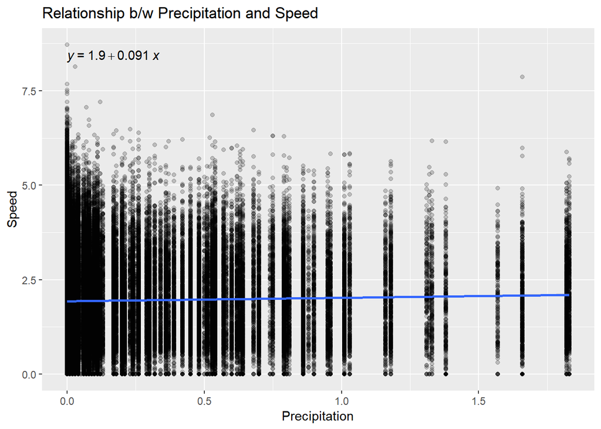

```r
prcpspeedchart <- ggplot(citimerged, aes(x = PRCP, y = speed)) + geom_point(alpha = 0.2) + geom_smooth(method = lm) + stat_regline_equation() + xlab("Precipitation") + ylab("Speed") + ggtitle("Relationship b/w Precipitation and Speed")
prcpspeedchart
```

Obviously no one likes to be in the rain. This is why we have plotted the relationship of precipitation and the speed of our riders. On those days where it rains, we see an increase in the speeds at which riders go. Connecting it back to our point on utilization, although there is likely to be lower risk of capacity problems on these days, it may not make sense to decrease the number of bikes on the street because there are always stations that are over utilized in neighborhoods like mahattan compared to others east of the city.

# What Effect Does Precipitation Have on the Distance of Trips?

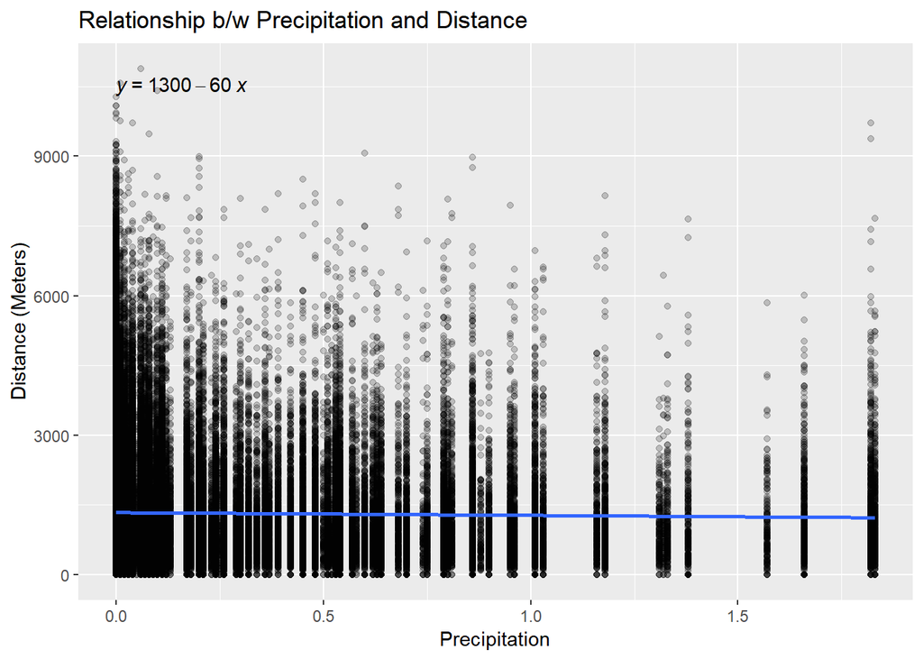

```r
prcpdistchart <- ggplot(citimerged, aes(x = PRCP, y = distmeters)) + geom_point(alpha = 0.2) + geom_smooth(method = lm) + stat_regline_equation() + xlab("Precipitation") + ylab("Distance (Meters)") + ggtitle("Relationship b/w Precipitation and Distance")
prcpdistchart
```

It makes sense that riders would travel less distance to stay out of the rain, but the overall trend does not seem to have all that much effect on the actual riders themselves. This means that the majority of our riders have to get to where they need to no matter the weather conditions. From this we can conclude that we are a key transportation resource for those who may not be able to afford other public transportation options and a motor vehicle. We should consider this when pricing our services for the annual subscription.